# Session 6. Tidyr, Dplyr

Parandzem Sargsyan, AUA, Metric

psargsyan@aua.am

October 5, 2019

Supplementary reading material: [R for Data Science, Hadley Wickham & Garrett Grolemund](https://www.bioinform.io/site/wp-content/uploads/2018/09/RDataScience.pdf)

# Introduction

Before doing data analysis, the data should go through data preparation process to make the data easier to work with. That process can contain several stages, one of which is data tidying.

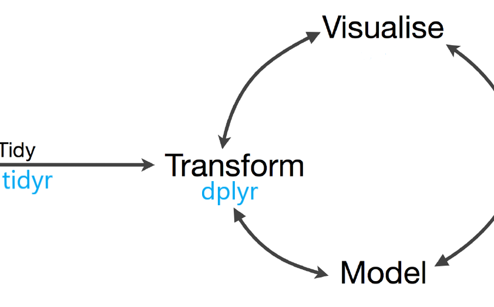

First, **tidyverse** package should be installed. This package is designed to make it easy to install and load multiple ‘tidyverse’ packages in a single step (e.g.tidyr, dbplyr,ggplot2,etc). To see more run **`packageDescription("tidyverse")`**.

```r
#install.packages("tidyverse",dependencies = TRUE)
library(tidyverse)
```

# tidyr

**`tidyr`** package provides a bunch of tools to help tidy up messy datasets.

The basic functions in `tidyr` that will help process, clean and manipulate data are the following ones which we will learn during this session:

- `spread()`
- `gather()`
- `separate()`
- `unite()`

Let’s take a look on 3 tables from tidyr package which represent the same data in different ways. **`view()`** can be used to see the data in a spreadsheet style in RStudio.

```r
tidyr:: table1
```

| country | year | cases | population |
| --- | --- | --- | --- |
| Afghanistan | 1999 | 745 | 19987071 |
| Afghanistan | 2000 | 2666 | 20595360 |
| Brazil | 1999 | 37737 | 172006362 |
| Brazil | 2000 | 80488 | 174504898 |
| China | 1999 | 212258 | 1272915272 |
| China | 2000 | 213766 | 1280428583 |

```r
tidyr:: table2
```

| country | year | type | count |
| --- | --- | --- | --- |
| Afghanistan | 1999 | cases | 745 |
| Afghanistan | 1999 | population | 19987071 |
| Afghanistan | 2000 | cases | 2666 |
| Afghanistan | 2000 | population | 20595360 |
| Brazil | 1999 | cases | 37737 |
| Brazil | 1999 | population | 172006362 |
| Brazil | 2000 | cases | 80488 |
| Brazil | 2000 | population | 174504898 |
| China | 1999 | cases | 212258 |
| China | 1999 | population | 1272915272 |

[output cut: 2 more lines]

```r
tidyr:: table3
```

|  | country | year | rate |
| --- | --- | --- | --- |
| 1 | Afghanistan | 1999 | 745/19987071 |
| 2 | Afghanistan | 2000 | 2666/20595360 |
| 3 | Brazil | 1999 | 37737/172006362 |
| 4 | Brazil | 2000 | 80488/174504898 |
| 5 | China | 1999 | 212258/1272915272 |
| 6 | China | 2000 | 213766/1280428583 |

From the above 3 tables, the tidy data will be the one which is much easier to work with. So, to make a dataset tidy there are three interrelated rules:

1. Each variable must have its own column.
2. Each observation must have its own row.
3. Each value must have its own cell.

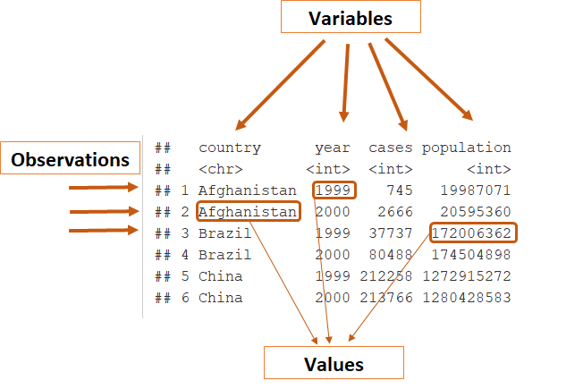

### Spread()

This function is used when an observation is spread out across multiple rows.

The table 2 above shows that for the same country and same year (e.g. Afghanistan 1999), there are two rows. Instead there should have been only one. Let’s bring the second table to the format of the first one by using `spread()` function.

```r
#1st option of the writing the code is with %>% operator
table2 %>%
  spread(key = type,
         value = count)
```

| country | year | cases | population |
| --- | --- | --- | --- |
| Afghanistan | 1999 | 745 | 19987071 |
| Afghanistan | 2000 | 2666 | 20595360 |
| Brazil | 1999 | 37737 | 172006362 |
| Brazil | 2000 | 80488 | 174504898 |
| China | 1999 | 212258 | 1272915272 |
| China | 2000 | 213766 | 1280428583 |

```r
spread(table2,
       key = type,
       value=count)
```

| country | year | cases | population |
| --- | --- | --- | --- |
| Afghanistan | 1999 | 745 | 19987071 |
| Afghanistan | 2000 | 2666 | 20595360 |
| Brazil | 1999 | 37737 | 172006362 |
| Brazil | 2000 | 80488 | 174504898 |
| China | 1999 | 212258 | 1272915272 |
| China | 2000 | 213766 | 1280428583 |

In the next codes, **%>%** operator will be used to call functions from the tidyr and dplyr packages just for the convinience. *To learn more about %>% operator go https://www.datacamp.com/community/tutorials/pipe-r-tutorial.*

### gather()

This function is used to bring common attributes of data together as one variable. Table4a below shows that “year” instead of being single variable apears as a heading of two separate columns.

```r
table4a
```

|  | country | 1999 | 2000 |
| --- | --- | --- | --- |
| 1 | Afghanistan | 745 | 2666 |
| 2 | Brazil | 37737 | 80488 |
| 3 | China | 212258 | 213766 |

So, let’s use `gather()` to bring Table4a into more structured format, i.e. create new column for “year” variable.

```r
tb4a<-table4a %>%
  gather(`1999`,`2000`,
         key = "year",
         value = "cases")
tb4a
```

| country | year | cases |
| --- | --- | --- |
| Afghanistan | 1999 | 745 |
| Brazil | 1999 | 37737 |
| China | 1999 | 212258 |
| Afghanistan | 2000 | 2666 |
| Brazil | 2000 | 80488 |
| China | 2000 | 213766 |

**Class Exercise**: Bring table4b into more structured format and join to table4a.

**Solution**

```r
tb4b<-table4b %>%
  gather(`1999`,`2000`,key = "year",value = "population")
tb4b
```

| country | year | population |
| --- | --- | --- |
| Afghanistan | 1999 | 19987071 |
| Brazil | 1999 | 172006362 |
| China | 1999 | 1272915272 |
| Afghanistan | 2000 | 20595360 |
| Brazil | 2000 | 174504898 |
| China | 2000 | 1280428583 |

Let’s join table4a and table4b to bring the tables in the format of table1.

```r
left_join(tb4a,tb4b, by=c("country","year"))
```

| country | year | cases | population |
| --- | --- | --- | --- |
| Afghanistan | 1999 | 745 | 19987071 |
| Brazil | 1999 | 37737 | 172006362 |
| China | 1999 | 212258 | 1272915272 |
| Afghanistan | 2000 | 2666 | 20595360 |
| Brazil | 2000 | 80488 | 174504898 |
| China | 2000 | 213766 | 1280428583 |

### separate()

This function splits a variable into two variables by splitting wherever a separator character appears. Table 3 below shows that “cases” and “population” appear as single variable and values are separated only by “/”.

```r
table3
```

|  | country | year | rate |
| --- | --- | --- | --- |
| 1 | Afghanistan | 1999 | 745/19987071 |
| 2 | Afghanistan | 2000 | 2666/20595360 |
| 3 | Brazil | 1999 | 37737/172006362 |
| 4 | Brazil | 2000 | 80488/174504898 |
| 5 | China | 1999 | 212258/1272915272 |
| 6 | China | 2000 | 213766/1280428583 |

So let’s use `separate()` funtion to create two separate variables for cases and population as it is in Table1.

```r
table3 %>%
  separate(rate, #the column, which should be separated
           into = c("cases","population"), #new column names
           sep="/" #indicates by which character to separate
)
```

| country | year | cases | population |
| --- | --- | --- | --- |
| Afghanistan | 1999 | 745 | 19987071 |
| Afghanistan | 2000 | 2666 | 20595360 |
| Brazil | 1999 | 37737 | 172006362 |
| Brazil | 2000 | 80488 | 174504898 |
| China | 1999 | 212258 | 1272915272 |
| China | 2000 | 213766 | 1280428583 |

From the new Table3 above, we see that types of cases and population variables are of character type instead of being *integer*. So let’s change the code above a little bit by setting right types of variables.

```r
table3 %>%
  separate(rate, #the column which should be separated
           into = c("cases","population"),  #new column names
           sep = "/", #separate by what
           convert = TRUE  #changing data type
)
```

| country | year | cases | population |
| --- | --- | --- | --- |
| Afghanistan | 1999 | 745 | 19987071 |
| Afghanistan | 2000 | 2666 | 20595360 |
| Brazil | 1999 | 37737 | 172006362 |
| Brazil | 2000 | 80488 | 174504898 |
| China | 1999 | 212258 | 1272915272 |
| China | 2000 | 213766 | 1280428583 |

**Class Exercise**: Separate year in table3 into two columns: 1st two digits-“century”, last tow digits-“year”.

**Solution**

```r
table3 %>%
  separate(year,
           into = c("century","year"),
           sep = 2, #defines how
           convert = TRUE
)
```

| country | century | year | rate |
| --- | --- | --- | --- |
| Afghanistan | 19 | 99 | 745/19987071 |
| Afghanistan | 20 | 0 | 2666/20595360 |
| Brazil | 19 | 99 | 37737/172006362 |
| Brazil | 20 | 0 | 80488/174504898 |
| China | 19 | 99 | 212258/1272915272 |
| China | 20 | 0 | 213766/1280428583 |

### Unite()

This function is the inverse of separate, i.e. it is used to merge two separate variables into one.

Let’s use Table 5 as an example.

```r
table5
```

|  | country | century | year | rate |
| --- | --- | --- | --- | --- |
| 1 | Afghanistan | 19 | 99 | 745/19987071 |
| 2 | Afghanistan | 20 | 00 | 2666/20595360 |
| 3 | Brazil | 19 | 99 | 37737/172006362 |
| 4 | Brazil | 20 | 00 | 80488/174504898 |
| 5 | China | 19 | 99 | 212258/1272915272 |
| 6 | China | 20 | 00 | 213766/1280428583 |

Let’s combine century and year.

```r
table5 %>%
  unite(new, #name of new column
        century, year #columns which should be combined
)
```

| country | new | rate |
| --- | --- | --- |
| Afghanistan | 19_99 | 745/19987071 |
| Afghanistan | 20_00 | 2666/20595360 |
| Brazil | 19_99 | 37737/172006362 |
| Brazil | 20_00 | 80488/174504898 |
| China | 19_99 | 212258/1272915272 |
| China | 20_00 | 213766/1280428583 |

**Note:** Automatically underscore (“_“) is created between combined values. Let’s modify the code above by putting”" which indicates that we don’t want any separator.

```r
table5 %>%
  unite(new, #name of new column
        century, year, #columns which should be combined
        sep="",
        remove = TRUE #removes  input columns
)
```

| country | new | rate |
| --- | --- | --- |
| Afghanistan | 1999 | 745/19987071 |
| Afghanistan | 2000 | 2666/20595360 |
| Brazil | 1999 | 37737/172006362 |
| Brazil | 2000 | 80488/174504898 |
| China | 1999 | 212258/1272915272 |
| China | 2000 | 213766/1280428583 |

# dplyr

The basic functions in `dplyr` that will help transform the data (e.g. create new variables, renale variables, or summarise) are the following ones which we will learn during this session:

- `filter()`
- `arrange()`
- `select()`
- `mutate()`
- `summarize()`
- `group_by()`

```r
#flights data will be used in the analysis
library(nycflights13)
```

```r
#let's see how the data looks like
data_flight<-nycflights13::flights
head(data_flight)
```

| year | month | day | dep_time | sched_dep_time | dep_delay | arr_time | sched_arr_time | arr_delay | carrier | flight | tailnum | origin | dest | air_time | distance | hour | minute | time_hour |
| --- | --- | --- | --- | --- | --- | --- | --- | --- | --- | --- | --- | --- | --- | --- | --- | --- | --- | --- |
| 2013 | 1 | 1 | 517 | 515 | 2 | 830 | 819 | 11 | UA | 1545 | N14228 | EWR | IAH | 227 | 1400 | 5 | 15 | 2013-01-01 05:00:00 |
| 2013 | 1 | 1 | 533 | 529 | 4 | 850 | 830 | 20 | UA | 1714 | N24211 | LGA | IAH | 227 | 1416 | 5 | 29 | 2013-01-01 05:00:00 |
| 2013 | 1 | 1 | 542 | 540 | 2 | 923 | 850 | 33 | AA | 1141 | N619AA | JFK | MIA | 160 | 1089 | 5 | 40 | 2013-01-01 05:00:00 |
| 2013 | 1 | 1 | 544 | 545 | -1 | 1004 | 1022 | -18 | B6 | 725 | N804JB | JFK | BQN | 183 | 1576 | 5 | 45 | 2013-01-01 05:00:00 |
| 2013 | 1 | 1 | 554 | 600 | -6 | 812 | 837 | -25 | DL | 461 | N668DN | LGA | ATL | 116 | 762 | 6 | 0 | 2013-01-01 06:00:00 |
| 2013 | 1 | 1 | 554 | 558 | -4 | 740 | 728 | 12 | UA | 1696 | N39463 | EWR | ORD | 150 | 719 | 5 | 58 | 2013-01-01 05:00:00 |

```r
str(data_flight)
```

```
Classes âtbl_dfâ, âtblâ and 'data.frame':   336776 obs. of  19 variables:
 $ year          : int  2013 2013 2013 2013 2013 2013 2013 2013 2013 2013 ...
 $ month         : int  1 1 1 1 1 1 1 1 1 1 ...
 $ day           : int  1 1 1 1 1 1 1 1 1 1 ...
 $ dep_time      : int  517 533 542 544 554 554 555 557 557 558 ...
 $ sched_dep_time: int  515 529 540 545 600 558 600 600 600 600 ...
 $ dep_delay     : num  2 4 2 -1 -6 -4 -5 -3 -3 -2 ...
 $ arr_time      : int  830 850 923 1004 812 740 913 709 838 753 ...
 $ sched_arr_time: int  819 830 850 1022 837 728 854 723 846 745 ...
 $ arr_delay     : num  11 20 33 -18 -25 12 19 -14 -8 8 ...
 $ carrier       : chr  "UA" "UA" "AA" "B6" ...
 $ flight        : int  1545 1714 1141 725 461 1696 507 5708 79 301 ...
 $ tailnum       : chr  "N14228" "N24211" "N619AA" "N804JB" ...
 $ origin        : chr  "EWR" "LGA" "JFK" "JFK" ...
 $ dest          : chr  "IAH" "IAH" "MIA" "BQN" ...
 $ air_time      : num  227 227 160 183 116 150 158 53 140 138 ...
 $ distance      : num  1400 1416 1089 1576 762 ...
 $ hour          : num  5 5 5 5 6 5 6 6 6 6 ...
 $ minute        : num  15 29 40 45 0 58 0 0 0 0 ...
 $ time_hour     : POSIXct, format: "2013-01-01 05:00:00" "2013-01-01 05:00:00" ...
```

### filter()

Picking observations by their values.

Operators for value picking: `>, >=, <, <=, != (not equal), and == (equal)`.

Let’s filter the data only for flights taken place in May.

```r
data_flight %>%
  filter(month==5)
```

| year | month | day | dep_time | sched_dep_time | dep_delay | arr_time | sched_arr_time | arr_delay | carrier | flight | tailnum | origin | dest | air_time | distance | hour | minute | time_hour |
| --- | --- | --- | --- | --- | --- | --- | --- | --- | --- | --- | --- | --- | --- | --- | --- | --- | --- | --- |
| 2013 | 5 | 1 | 9 | 1655 | 434 | 308 | 2020 | 408 | VX | 413 | N628VA | JFK | LAX | 341 | 2475 | 16 | 55 | 2013-05-01 16:00:00 |
| 2013 | 5 | 1 | 451 | 500 | -9 | 641 | 640 | 1 | US | 1219 | N196UW | EWR | CLT | 94 | 529 | 5 | 0 | 2013-05-01 05:00:00 |
| 2013 | 5 | 1 | 537 | 540 | -3 | 836 | 840 | -4 | AA | 701 | N5BYAA | JFK | MIA | 144 | 1089 | 5 | 40 | 2013-05-01 05:00:00 |
| 2013 | 5 | 1 | 544 | 545 | -1 | 818 | 827 | -9 | UA | 450 | N494UA | LGA | IAH | 190 | 1416 | 5 | 45 | 2013-05-01 05:00:00 |
| 2013 | 5 | 1 | 548 | 600 | -12 | 831 | 854 | -23 | B6 | 371 | N523JB | LGA | FLL | 140 | 1076 | 6 | 0 | 2013-05-01 06:00:00 |
| 2013 | 5 | 1 | 549 | 600 | -11 | 804 | 810 | -6 | MQ | 4650 | N520MQ | LGA | ATL | 113 | 762 | 6 | 0 | 2013-05-01 06:00:00 |
| 2013 | 5 | 1 | 553 | 600 | -7 | 700 | 712 | -12 | EV | 5747 | N877AS | LGA | IAD | 48 | 229 | 6 | 0 | 2013-05-01 06:00:00 |
| 2013 | 5 | 1 | 553 | 600 | -7 | 655 | 701 | -6 | US | 2114 | N702UW | LGA | BOS | 35 | 184 | 6 | 0 | 2013-05-01 06:00:00 |
| 2013 | 5 | 1 | 554 | 600 | -6 | 731 | 756 | -25 | DL | 731 | N327NB | LGA | DTW | 74 | 502 | 6 | 0 | 2013-05-01 06:00:00 |
| 2013 | 5 | 1 | 554 | 600 | -6 | 707 | 725 | -18 | UA | 635 | N439UA | LGA | ORD | 112 | 733 | 6 | 0 | 2013-05-01 06:00:00 |

[output cut: 990 more lines]

Let’s filter flights with more than 12 hour and destination was LAX.

```r
data_flight %>%
  filter(hour>12,dest=="LAX") #multiple imput means "AND", i.e. both expressions must be true.
```

| year | month | day | dep_time | sched_dep_time | dep_delay | arr_time | sched_arr_time | arr_delay | carrier | flight | tailnum | origin | dest | air_time | distance | hour | minute | time_hour |
| --- | --- | --- | --- | --- | --- | --- | --- | --- | --- | --- | --- | --- | --- | --- | --- | --- | --- | --- |
| 2013 | 1 | 1 | 1320 | 1320 | 0 | 1625 | 1636 | -11 | UA | 1425 | N58101 | EWR | LAX | 334 | 2454 | 13 | 20 | 2013-01-01 13:00:00 |
| 2013 | 1 | 1 | 1327 | 1330 | -3 | 1638 | 1655 | -17 | VX | 411 | N642VA | JFK | LAX | 352 | 2475 | 13 | 30 | 2013-01-01 13:00:00 |
| 2013 | 1 | 1 | 1341 | 1345 | -4 | 1709 | 1705 | 4 | AA | 117 | N339AA | JFK | LAX | 362 | 2475 | 13 | 45 | 2013-01-01 13:00:00 |
| 2013 | 1 | 1 | 1454 | 1500 | -6 | 1815 | 1837 | -22 | DL | 1467 | N702TW | JFK | LAX | 340 | 2475 | 15 | 0 | 2013-01-01 15:00:00 |
| 2013 | 1 | 1 | 1522 | 1530 | -8 | 1858 | 1855 | 3 | UA | 530 | N512UA | JFK | LAX | 356 | 2475 | 15 | 30 | 2013-01-01 15:00:00 |
| 2013 | 1 | 1 | 1523 | 1516 | 7 | 1831 | 1828 | 3 | UA | 1600 | N18112 | EWR | LAX | 337 | 2454 | 15 | 16 | 2013-01-01 15:00:00 |
| 2013 | 1 | 1 | 1539 | 1545 | -6 | 1853 | 1910 | -17 | AA | 133 | N319AA | JFK | LAX | 351 | 2475 | 15 | 45 | 2013-01-01 15:00:00 |
| 2013 | 1 | 1 | 1626 | 1630 | -4 | 2007 | 1952 | 15 | B6 | 675 | N804JB | JFK | LAX | 370 | 2475 | 16 | 30 | 2013-01-01 16:00:00 |
| 2013 | 1 | 1 | 1655 | 1655 | 0 | 2025 | 2030 | -5 | VX | 413 | N626VA | JFK | LAX | 362 | 2475 | 16 | 55 | 2013-01-01 16:00:00 |
| 2013 | 1 | 1 | 1707 | 1700 | 7 | 2006 | 2000 | 6 | UA | 342 | N543UA | EWR | LAX | 334 | 2454 | 17 | 0 | 2013-01-01 17:00:00 |

[output cut: 990 more lines]

Other logical operators to use in the filter():

- `&` is “and”,
- `|` is “or”,
- `!` is “not”

Let’s filter for flights that taken place either on May *OR* June:

```r
data_flight %>%
  filter(month==5 | month==6)
```

| year | month | day | dep_time | sched_dep_time | dep_delay | arr_time | sched_arr_time | arr_delay | carrier | flight | tailnum | origin | dest | air_time | distance | hour | minute | time_hour |
| --- | --- | --- | --- | --- | --- | --- | --- | --- | --- | --- | --- | --- | --- | --- | --- | --- | --- | --- |
| 2013 | 5 | 1 | 9 | 1655 | 434 | 308 | 2020 | 408 | VX | 413 | N628VA | JFK | LAX | 341 | 2475 | 16 | 55 | 2013-05-01 16:00:00 |
| 2013 | 5 | 1 | 451 | 500 | -9 | 641 | 640 | 1 | US | 1219 | N196UW | EWR | CLT | 94 | 529 | 5 | 0 | 2013-05-01 05:00:00 |
| 2013 | 5 | 1 | 537 | 540 | -3 | 836 | 840 | -4 | AA | 701 | N5BYAA | JFK | MIA | 144 | 1089 | 5 | 40 | 2013-05-01 05:00:00 |
| 2013 | 5 | 1 | 544 | 545 | -1 | 818 | 827 | -9 | UA | 450 | N494UA | LGA | IAH | 190 | 1416 | 5 | 45 | 2013-05-01 05:00:00 |
| 2013 | 5 | 1 | 548 | 600 | -12 | 831 | 854 | -23 | B6 | 371 | N523JB | LGA | FLL | 140 | 1076 | 6 | 0 | 2013-05-01 06:00:00 |
| 2013 | 5 | 1 | 549 | 600 | -11 | 804 | 810 | -6 | MQ | 4650 | N520MQ | LGA | ATL | 113 | 762 | 6 | 0 | 2013-05-01 06:00:00 |
| 2013 | 5 | 1 | 553 | 600 | -7 | 700 | 712 | -12 | EV | 5747 | N877AS | LGA | IAD | 48 | 229 | 6 | 0 | 2013-05-01 06:00:00 |
| 2013 | 5 | 1 | 553 | 600 | -7 | 655 | 701 | -6 | US | 2114 | N702UW | LGA | BOS | 35 | 184 | 6 | 0 | 2013-05-01 06:00:00 |
| 2013 | 5 | 1 | 554 | 600 | -6 | 731 | 756 | -25 | DL | 731 | N327NB | LGA | DTW | 74 | 502 | 6 | 0 | 2013-05-01 06:00:00 |
| 2013 | 5 | 1 | 554 | 600 | -6 | 707 | 725 | -18 | UA | 635 | N439UA | LGA | ORD | 112 | 733 | 6 | 0 | 2013-05-01 06:00:00 |

[output cut: 990 more lines]

```r
data_flight %>%
  filter(month %in% c(5,6))
```

| year | month | day | dep_time | sched_dep_time | dep_delay | arr_time | sched_arr_time | arr_delay | carrier | flight | tailnum | origin | dest | air_time | distance | hour | minute | time_hour |
| --- | --- | --- | --- | --- | --- | --- | --- | --- | --- | --- | --- | --- | --- | --- | --- | --- | --- | --- |
| 2013 | 5 | 1 | 9 | 1655 | 434 | 308 | 2020 | 408 | VX | 413 | N628VA | JFK | LAX | 341 | 2475 | 16 | 55 | 2013-05-01 16:00:00 |
| 2013 | 5 | 1 | 451 | 500 | -9 | 641 | 640 | 1 | US | 1219 | N196UW | EWR | CLT | 94 | 529 | 5 | 0 | 2013-05-01 05:00:00 |
| 2013 | 5 | 1 | 537 | 540 | -3 | 836 | 840 | -4 | AA | 701 | N5BYAA | JFK | MIA | 144 | 1089 | 5 | 40 | 2013-05-01 05:00:00 |
| 2013 | 5 | 1 | 544 | 545 | -1 | 818 | 827 | -9 | UA | 450 | N494UA | LGA | IAH | 190 | 1416 | 5 | 45 | 2013-05-01 05:00:00 |
| 2013 | 5 | 1 | 548 | 600 | -12 | 831 | 854 | -23 | B6 | 371 | N523JB | LGA | FLL | 140 | 1076 | 6 | 0 | 2013-05-01 06:00:00 |
| 2013 | 5 | 1 | 549 | 600 | -11 | 804 | 810 | -6 | MQ | 4650 | N520MQ | LGA | ATL | 113 | 762 | 6 | 0 | 2013-05-01 06:00:00 |
| 2013 | 5 | 1 | 553 | 600 | -7 | 700 | 712 | -12 | EV | 5747 | N877AS | LGA | IAD | 48 | 229 | 6 | 0 | 2013-05-01 06:00:00 |
| 2013 | 5 | 1 | 553 | 600 | -7 | 655 | 701 | -6 | US | 2114 | N702UW | LGA | BOS | 35 | 184 | 6 | 0 | 2013-05-01 06:00:00 |
| 2013 | 5 | 1 | 554 | 600 | -6 | 731 | 756 | -25 | DL | 731 | N327NB | LGA | DTW | 74 | 502 | 6 | 0 | 2013-05-01 06:00:00 |
| 2013 | 5 | 1 | 554 | 600 | -6 | 707 | 725 | -18 | UA | 635 | N439UA | LGA | ORD | 112 | 733 | 6 | 0 | 2013-05-01 06:00:00 |

[output cut: 990 more lines]

filtering for missing data:

```r
data_flight %>%
  filter(is.na(dep_delay) & is.na(arr_time))
```

| year | month | day | dep_time | sched_dep_time | dep_delay | arr_time | sched_arr_time | arr_delay | carrier | flight | tailnum | origin | dest | air_time | distance | hour | minute | time_hour |
| --- | --- | --- | --- | --- | --- | --- | --- | --- | --- | --- | --- | --- | --- | --- | --- | --- | --- | --- |
| 2013 | 1 | 1 | NA | 1630 | NA | NA | 1815 | NA | EV | 4308 | N18120 | EWR | RDU | NA | 416 | 16 | 30 | 2013-01-01 16:00:00 |
| 2013 | 1 | 1 | NA | 1935 | NA | NA | 2240 | NA | AA | 791 | N3EHAA | LGA | DFW | NA | 1389 | 19 | 35 | 2013-01-01 19:00:00 |
| 2013 | 1 | 1 | NA | 1500 | NA | NA | 1825 | NA | AA | 1925 | N3EVAA | LGA | MIA | NA | 1096 | 15 | 0 | 2013-01-01 15:00:00 |
| 2013 | 1 | 1 | NA | 600 | NA | NA | 901 | NA | B6 | 125 | N618JB | JFK | FLL | NA | 1069 | 6 | 0 | 2013-01-01 06:00:00 |
| 2013 | 1 | 2 | NA | 1540 | NA | NA | 1747 | NA | EV | 4352 | N10575 | EWR | CVG | NA | 569 | 15 | 40 | 2013-01-02 15:00:00 |
| 2013 | 1 | 2 | NA | 1620 | NA | NA | 1746 | NA | EV | 4406 | N13949 | EWR | PIT | NA | 319 | 16 | 20 | 2013-01-02 16:00:00 |
| 2013 | 1 | 2 | NA | 1355 | NA | NA | 1459 | NA | EV | 4434 | N10575 | EWR | MHT | NA | 209 | 13 | 55 | 2013-01-02 13:00:00 |
| 2013 | 1 | 2 | NA | 1420 | NA | NA | 1644 | NA | EV | 4935 | N759EV | EWR | ATL | NA | 746 | 14 | 20 | 2013-01-02 14:00:00 |
| 2013 | 1 | 2 | NA | 1321 | NA | NA | 1536 | NA | EV | 3849 | N13550 | EWR | IND | NA | 645 | 13 | 21 | 2013-01-02 13:00:00 |
| 2013 | 1 | 2 | NA | 1545 | NA | NA | 1910 | NA | AA | 133 | NA | JFK | LAX | NA | 2475 | 15 | 45 | 2013-01-02 15:00:00 |

[output cut: 990 more lines]

### arrange()

Reordering the rows.

```r
data_flight %>%
  arrange(year, day, month)
```

| year | month | day | dep_time | sched_dep_time | dep_delay | arr_time | sched_arr_time | arr_delay | carrier | flight | tailnum | origin | dest | air_time | distance | hour | minute | time_hour |
| --- | --- | --- | --- | --- | --- | --- | --- | --- | --- | --- | --- | --- | --- | --- | --- | --- | --- | --- |
| 2013 | 1 | 1 | 517 | 515 | 2 | 830 | 819 | 11 | UA | 1545 | N14228 | EWR | IAH | 227 | 1400 | 5 | 15 | 2013-01-01 05:00:00 |
| 2013 | 1 | 1 | 533 | 529 | 4 | 850 | 830 | 20 | UA | 1714 | N24211 | LGA | IAH | 227 | 1416 | 5 | 29 | 2013-01-01 05:00:00 |
| 2013 | 1 | 1 | 542 | 540 | 2 | 923 | 850 | 33 | AA | 1141 | N619AA | JFK | MIA | 160 | 1089 | 5 | 40 | 2013-01-01 05:00:00 |
| 2013 | 1 | 1 | 544 | 545 | -1 | 1004 | 1022 | -18 | B6 | 725 | N804JB | JFK | BQN | 183 | 1576 | 5 | 45 | 2013-01-01 05:00:00 |
| 2013 | 1 | 1 | 554 | 600 | -6 | 812 | 837 | -25 | DL | 461 | N668DN | LGA | ATL | 116 | 762 | 6 | 0 | 2013-01-01 06:00:00 |
| 2013 | 1 | 1 | 554 | 558 | -4 | 740 | 728 | 12 | UA | 1696 | N39463 | EWR | ORD | 150 | 719 | 5 | 58 | 2013-01-01 05:00:00 |
| 2013 | 1 | 1 | 555 | 600 | -5 | 913 | 854 | 19 | B6 | 507 | N516JB | EWR | FLL | 158 | 1065 | 6 | 0 | 2013-01-01 06:00:00 |
| 2013 | 1 | 1 | 557 | 600 | -3 | 709 | 723 | -14 | EV | 5708 | N829AS | LGA | IAD | 53 | 229 | 6 | 0 | 2013-01-01 06:00:00 |
| 2013 | 1 | 1 | 557 | 600 | -3 | 838 | 846 | -8 | B6 | 79 | N593JB | JFK | MCO | 140 | 944 | 6 | 0 | 2013-01-01 06:00:00 |
| 2013 | 1 | 1 | 558 | 600 | -2 | 753 | 745 | 8 | AA | 301 | N3ALAA | LGA | ORD | 138 | 733 | 6 | 0 | 2013-01-01 06:00:00 |

[output cut: 990 more lines]

Use desc() to re-order by a column in descending order:

```r
data_flight %>%
  arrange(desc(month))
```

| year | month | day | dep_time | sched_dep_time | dep_delay | arr_time | sched_arr_time | arr_delay | carrier | flight | tailnum | origin | dest | air_time | distance | hour | minute | time_hour |
| --- | --- | --- | --- | --- | --- | --- | --- | --- | --- | --- | --- | --- | --- | --- | --- | --- | --- | --- |
| 2013 | 12 | 1 | 13 | 2359 | 14 | 446 | 445 | 1 | B6 | 745 | N715JB | JFK | PSE | 195 | 1617 | 23 | 59 | 2013-12-01 23:00:00 |
| 2013 | 12 | 1 | 17 | 2359 | 18 | 443 | 437 | 6 | B6 | 839 | N593JB | JFK | BQN | 186 | 1576 | 23 | 59 | 2013-12-01 23:00:00 |
| 2013 | 12 | 1 | 453 | 500 | -7 | 636 | 651 | -15 | US | 1895 | N197UW | EWR | CLT | 86 | 529 | 5 | 0 | 2013-12-01 05:00:00 |
| 2013 | 12 | 1 | 520 | 515 | 5 | 749 | 808 | -19 | UA | 1487 | N69804 | EWR | IAH | 193 | 1400 | 5 | 15 | 2013-12-01 05:00:00 |
| 2013 | 12 | 1 | 536 | 540 | -4 | 845 | 850 | -5 | AA | 2243 | N634AA | JFK | MIA | 144 | 1089 | 5 | 40 | 2013-12-01 05:00:00 |
| 2013 | 12 | 1 | 540 | 550 | -10 | 1005 | 1027 | -22 | B6 | 939 | N821JB | JFK | BQN | 189 | 1576 | 5 | 50 | 2013-12-01 05:00:00 |
| 2013 | 12 | 1 | 541 | 545 | -4 | 734 | 755 | -21 | EV | 3819 | N13968 | EWR | CVG | 95 | 569 | 5 | 45 | 2013-12-01 05:00:00 |
| 2013 | 12 | 1 | 546 | 545 | 1 | 826 | 835 | -9 | UA | 1441 | N23708 | LGA | IAH | 204 | 1416 | 5 | 45 | 2013-12-01 05:00:00 |
| 2013 | 12 | 1 | 549 | 600 | -11 | 648 | 659 | -11 | US | 2167 | N945UW | LGA | DCA | 42 | 214 | 6 | 0 | 2013-12-01 06:00:00 |
| 2013 | 12 | 1 | 550 | 600 | -10 | 825 | 854 | -29 | B6 | 605 | N706JB | EWR | FLL | 140 | 1065 | 6 | 0 | 2013-12-01 06:00:00 |

[output cut: 990 more lines]

### select()

From the data, picking only several variables by their names.

```r
data_flight %>%
  select(month,day,dep_time, arr_time)
```

| month | day | dep_time | arr_time |
| --- | --- | --- | --- |
| 1 | 1 | 517 | 830 |
| 1 | 1 | 533 | 850 |
| 1 | 1 | 542 | 923 |
| 1 | 1 | 544 | 1004 |
| 1 | 1 | 554 | 812 |
| 1 | 1 | 554 | 740 |
| 1 | 1 | 555 | 913 |
| 1 | 1 | 557 | 709 |
| 1 | 1 | 557 | 838 |
| 1 | 1 | 558 | 753 |

[output cut: 990 more lines]

```r
# Select all columns between year and day (inclusive)
data_flight %>%
  select(year:day)
```

| year | month | day |
| --- | --- | --- |
| 2013 | 1 | 1 |
| 2013 | 1 | 1 |
| 2013 | 1 | 1 |
| 2013 | 1 | 1 |
| 2013 | 1 | 1 |
| 2013 | 1 | 1 |
| 2013 | 1 | 1 |
| 2013 | 1 | 1 |
| 2013 | 1 | 1 |
| 2013 | 1 | 1 |

[output cut: 990 more lines]

```r
# Select all columns except year and day
data_flight %>%
  select(-(year:day))
```

| dep_time | sched_dep_time | dep_delay | arr_time | sched_arr_time | arr_delay | carrier | flight | tailnum | origin | dest | air_time | distance | hour | minute | time_hour |
| --- | --- | --- | --- | --- | --- | --- | --- | --- | --- | --- | --- | --- | --- | --- | --- |
| 517 | 515 | 2 | 830 | 819 | 11 | UA | 1545 | N14228 | EWR | IAH | 227 | 1400 | 5 | 15 | 2013-01-01 05:00:00 |
| 533 | 529 | 4 | 850 | 830 | 20 | UA | 1714 | N24211 | LGA | IAH | 227 | 1416 | 5 | 29 | 2013-01-01 05:00:00 |
| 542 | 540 | 2 | 923 | 850 | 33 | AA | 1141 | N619AA | JFK | MIA | 160 | 1089 | 5 | 40 | 2013-01-01 05:00:00 |
| 544 | 545 | -1 | 1004 | 1022 | -18 | B6 | 725 | N804JB | JFK | BQN | 183 | 1576 | 5 | 45 | 2013-01-01 05:00:00 |
| 554 | 600 | -6 | 812 | 837 | -25 | DL | 461 | N668DN | LGA | ATL | 116 | 762 | 6 | 0 | 2013-01-01 06:00:00 |
| 554 | 558 | -4 | 740 | 728 | 12 | UA | 1696 | N39463 | EWR | ORD | 150 | 719 | 5 | 58 | 2013-01-01 05:00:00 |
| 555 | 600 | -5 | 913 | 854 | 19 | B6 | 507 | N516JB | EWR | FLL | 158 | 1065 | 6 | 0 | 2013-01-01 06:00:00 |
| 557 | 600 | -3 | 709 | 723 | -14 | EV | 5708 | N829AS | LGA | IAD | 53 | 229 | 6 | 0 | 2013-01-01 06:00:00 |
| 557 | 600 | -3 | 838 | 846 | -8 | B6 | 79 | N593JB | JFK | MCO | 140 | 944 | 6 | 0 | 2013-01-01 06:00:00 |
| 558 | 600 | -2 | 753 | 745 | 8 | AA | 301 | N3ALAA | LGA | ORD | 138 | 733 | 6 | 0 | 2013-01-01 06:00:00 |

[output cut: 990 more lines]

Some useful function to help to filter:

- `starts_with("abc")`: matches names that begin with “abc”.
- `ends_with("xyz")`: matches names that end with “xyz”.
- `contains("ijk")`: matches names that contain “ijk”.

```r
data_flight %>%
  select(starts_with("dep"))
```

| dep_time | dep_delay |
| --- | --- |
| 517 | 2 |
| 533 | 4 |
| 542 | 2 |
| 544 | -1 |
| 554 | -6 |
| 554 | -4 |
| 555 | -5 |
| 557 | -3 |
| 557 | -3 |
| 558 | -2 |

[output cut: 990 more lines]

```r
data_flight %>%
  select(contains("sch"))
```

| sched_dep_time | sched_arr_time |
| --- | --- |
| 515 | 819 |
| 529 | 830 |
| 540 | 850 |
| 545 | 1022 |
| 600 | 837 |
| 558 | 728 |
| 600 | 854 |
| 600 | 723 |
| 600 | 846 |
| 600 | 745 |

[output cut: 990 more lines]

### mutate()

Creating new variables with functions of existing variables. The main arithmetic operators can be used to create new variables: `+, -, *, /, ^`.

```r
data_flight %>%
  mutate(difference=dep_delay - arr_delay)
```

| year | month | day | dep_time | sched_dep_time | dep_delay | arr_time | sched_arr_time | arr_delay | carrier | flight | tailnum | origin | dest | air_time | distance | hour | minute | time_hour | difference |
| --- | --- | --- | --- | --- | --- | --- | --- | --- | --- | --- | --- | --- | --- | --- | --- | --- | --- | --- | --- |
| 2013 | 1 | 1 | 517 | 515 | 2 | 830 | 819 | 11 | UA | 1545 | N14228 | EWR | IAH | 227 | 1400 | 5 | 15 | 2013-01-01 05:00:00 | -9 |
| 2013 | 1 | 1 | 533 | 529 | 4 | 850 | 830 | 20 | UA | 1714 | N24211 | LGA | IAH | 227 | 1416 | 5 | 29 | 2013-01-01 05:00:00 | -16 |
| 2013 | 1 | 1 | 542 | 540 | 2 | 923 | 850 | 33 | AA | 1141 | N619AA | JFK | MIA | 160 | 1089 | 5 | 40 | 2013-01-01 05:00:00 | -31 |
| 2013 | 1 | 1 | 544 | 545 | -1 | 1004 | 1022 | -18 | B6 | 725 | N804JB | JFK | BQN | 183 | 1576 | 5 | 45 | 2013-01-01 05:00:00 | 17 |
| 2013 | 1 | 1 | 554 | 600 | -6 | 812 | 837 | -25 | DL | 461 | N668DN | LGA | ATL | 116 | 762 | 6 | 0 | 2013-01-01 06:00:00 | 19 |
| 2013 | 1 | 1 | 554 | 558 | -4 | 740 | 728 | 12 | UA | 1696 | N39463 | EWR | ORD | 150 | 719 | 5 | 58 | 2013-01-01 05:00:00 | -16 |
| 2013 | 1 | 1 | 555 | 600 | -5 | 913 | 854 | 19 | B6 | 507 | N516JB | EWR | FLL | 158 | 1065 | 6 | 0 | 2013-01-01 06:00:00 | -24 |
| 2013 | 1 | 1 | 557 | 600 | -3 | 709 | 723 | -14 | EV | 5708 | N829AS | LGA | IAD | 53 | 229 | 6 | 0 | 2013-01-01 06:00:00 | 11 |
| 2013 | 1 | 1 | 557 | 600 | -3 | 838 | 846 | -8 | B6 | 79 | N593JB | JFK | MCO | 140 | 944 | 6 | 0 | 2013-01-01 06:00:00 | 5 |
| 2013 | 1 | 1 | 558 | 600 | -2 | 753 | 745 | 8 | AA | 301 | N3ALAA | LGA | ORD | 138 | 733 | 6 | 0 | 2013-01-01 06:00:00 | -10 |

[output cut: 990 more lines]

let’s bring a new variable to the beginning.

```r
data_flight %>%
  mutate(difference=dep_delay - arr_delay) %>%
  select(difference,everything())
```

| difference | year | month | day | dep_time | sched_dep_time | dep_delay | arr_time | sched_arr_time | arr_delay | carrier | flight | tailnum | origin | dest | air_time | distance | hour | minute | time_hour |
| --- | --- | --- | --- | --- | --- | --- | --- | --- | --- | --- | --- | --- | --- | --- | --- | --- | --- | --- | --- |
| -9 | 2013 | 1 | 1 | 517 | 515 | 2 | 830 | 819 | 11 | UA | 1545 | N14228 | EWR | IAH | 227 | 1400 | 5 | 15 | 2013-01-01 05:00:00 |
| -16 | 2013 | 1 | 1 | 533 | 529 | 4 | 850 | 830 | 20 | UA | 1714 | N24211 | LGA | IAH | 227 | 1416 | 5 | 29 | 2013-01-01 05:00:00 |
| -31 | 2013 | 1 | 1 | 542 | 540 | 2 | 923 | 850 | 33 | AA | 1141 | N619AA | JFK | MIA | 160 | 1089 | 5 | 40 | 2013-01-01 05:00:00 |
| 17 | 2013 | 1 | 1 | 544 | 545 | -1 | 1004 | 1022 | -18 | B6 | 725 | N804JB | JFK | BQN | 183 | 1576 | 5 | 45 | 2013-01-01 05:00:00 |
| 19 | 2013 | 1 | 1 | 554 | 600 | -6 | 812 | 837 | -25 | DL | 461 | N668DN | LGA | ATL | 116 | 762 | 6 | 0 | 2013-01-01 06:00:00 |
| -16 | 2013 | 1 | 1 | 554 | 558 | -4 | 740 | 728 | 12 | UA | 1696 | N39463 | EWR | ORD | 150 | 719 | 5 | 58 | 2013-01-01 05:00:00 |
| -24 | 2013 | 1 | 1 | 555 | 600 | -5 | 913 | 854 | 19 | B6 | 507 | N516JB | EWR | FLL | 158 | 1065 | 6 | 0 | 2013-01-01 06:00:00 |
| 11 | 2013 | 1 | 1 | 557 | 600 | -3 | 709 | 723 | -14 | EV | 5708 | N829AS | LGA | IAD | 53 | 229 | 6 | 0 | 2013-01-01 06:00:00 |
| 5 | 2013 | 1 | 1 | 557 | 600 | -3 | 838 | 846 | -8 | B6 | 79 | N593JB | JFK | MCO | 140 | 944 | 6 | 0 | 2013-01-01 06:00:00 |
| -10 | 2013 | 1 | 1 | 558 | 600 | -2 | 753 | 745 | 8 | AA | 301 | N3ALAA | LGA | ORD | 138 | 733 | 6 | 0 | 2013-01-01 06:00:00 |

[output cut: 990 more lines]

If you only want to keep the new variables, use transmute():

```r
data_flight %>%
  transmute(difference=dep_delay - arr_delay)
```

| difference |
| --- |
| -9 |
| -16 |
| -31 |
| 17 |
| 19 |
| -16 |
| -24 |
| 11 |
| 5 |
| -10 |

[output cut: 990 more lines]

### summarize(),group_by()

summarize: Collapsing many values down to a single summary.

group_by: this function changes the scope of each function from operating on the entire dataset to operating on it group-by-group.

```r
data_flight %>%
  summarise(delay = mean(dep_delay, na.rm = TRUE))
```

| delay |
| --- |
| 12.63907 |

```r
data_flight %>%
  summarise(median(hour, na.rm = TRUE))
```

| median(hour, na.rm = TRUE) |
| --- |
| 13 |

Let’s calculate average delay for each month.

```r
data_flight %>%
  group_by(month) %>% #first we need to group data by month
  summarise(delay=mean(dep_delay, na.rm = TRUE)) #then for each month calculate mean delay
```

| month | delay |
| --- | --- |
| 1 | 10.036665 |
| 2 | 10.816843 |
| 3 | 13.227076 |
| 4 | 13.938038 |
| 5 | 12.986859 |
| 6 | 20.846332 |
| 7 | 21.727787 |
| 8 | 12.611040 |
| 9 | 6.722476 |
| 10 | 6.243988 |

[output cut: 2 more lines]

**Class exercise**:

1. group by destination
2. calculate how many flights each destination has
3. calculate average delay
4. calculate average distance
5. visualise relationship between delay and distance

**Solution**

```r
sum_data<-data_flight %>%
  group_by(dest) %>%
  summarise(
    avg_delay=mean(arr_delay+dep_delay,na.rm = TRUE),
    avg_distance=mean(distance,na.rm = TRUE),
    num_flights=n()
  )
sum_data
```

| dest | avg_delay | avg_distance | num_flights |
| --- | --- | --- | --- |
| ABQ | 18.1220472 | 1826.00000 | 254 |
| ACK | 11.2992424 | 199.00000 | 265 |
| ALB | 37.8444976 | 143.00000 | 439 |
| ANC | 10.3750000 | 3370.00000 | 8 |
| ATL | 23.7252480 | 757.10822 | 17215 |
| AUS | 19.0369141 | 1514.25297 | 2439 |
| AVL | 16.1532567 | 583.58182 | 275 |
| BDL | 24.7694175 | 116.00000 | 443 |
| BGR | 27.1843575 | 378.00000 | 375 |
| BHM | 45.8921933 | 865.99663 | 297 |

[output cut: 95 more lines]

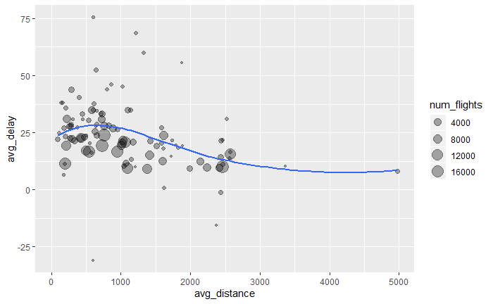

```r
ggplot(sum_data)+
  geom_point(mapping = aes(x = avg_distance, y=avg_delay, size=num_flights),alpha=1/3)+
  geom_smooth(mapping = aes(x = avg_distance, y=avg_delay),se = FALSE)
```

The graph above shows that delays increase when distance is up to 700-800miles, after which the delay starts decreasing.